# Project 2: Supervised Learning

#### Observartion

Receiver Operating Characteristic (ROC):curve is another common tool used with binary classifiers.  
The dotted line represents the ROC curve of a purely random classifier;  
good classifier stays as far away from that line as possible (toward the top-left corner). From our Model, the curve stays really faraway which is a good indicator of good model.

#### e.Balance the data using the right balancing technique.

The given data is not balanced

```python
customerdata['LoanOnCard'].value_counts()
```

```
0    4500
1     480
Name: LoanOnCard, dtype: int64
```

```python
totalcount=customerdata['LoanOnCard'].size
totalcount
```

```
4980
```

```python
len(customerdata[customerdata['LoanOnCard']==0])
```

```
4500
```

```python
LoanOnCard_No_percentage  = (len(customerdata[customerdata['LoanOnCard']==0])/4980)*100
LoanOnCard_percentage =  (len(customerdata[customerdata['LoanOnCard']==1])/4980)*100
print('LoanOnCard_No_percentage  {:.2f}'.format(LoanOnCard_No_percentage))
print('LoanOnCard_percentage {:.2f}'.format(LoanOnCard_percentage))
```

```
LoanOnCard_No_percentage  90.36
LoanOnCard_percentage 9.64
```

#### Observation:

The percentage of minority class proportion is around 10% which is **Moderate** Imbalanced Class. Imbalance data creates bias as machine learning model tend to predict the majority class.

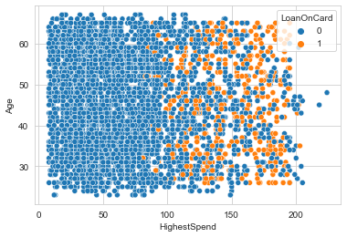

```python
import pandas as pd
import seaborn as sns
#Here I would only use two continuous features CreditScore and Age with the target LoanOnCard
df = customerdata[['HighestSpend', 'Age', 'LoanOnCard']]
sns.scatterplot(data = df, x ='HighestSpend', y = 'Age', hue = 'LoanOnCard')
```

```python
data=customerdata.copy()
from sklearn.model_selection import train_test_split
# Split data into X and Y
# Create a separate dataframe consisting only of the features i.e independent attributes
X = data.drop(labels= "LoanOnCard" , axis = 1)
y = data["LoanOnCard"]
X.head()
```

|  | Age | CustomerSince | HighestSpend | HiddenScore | MonthlyAverageSpend | Level | Mortgage | Security | FixedDepositAccount | InternetBanking | CreditCard |
| --- | --- | --- | --- | --- | --- | --- | --- | --- | --- | --- | --- |
| 9 | 34 | 9 | 180 | 1 | 8.9 | 3 | 0 | 0 | 0 | 0 | 0 |
| 10 | 65 | 39 | 105 | 4 | 2.4 | 3 | 0 | 0 | 0 | 0 | 0 |
| 11 | 29 | 5 | 45 | 3 | 0.1 | 2 | 0 | 0 | 0 | 1 | 0 |
| 12 | 48 | 23 | 114 | 2 | 3.8 | 3 | 0 | 1 | 0 | 0 | 0 |
| 13 | 59 | 32 | 40 | 4 | 2.5 | 2 | 0 | 0 | 0 | 1 | 0 |

```python
#np.random.seed(0)
#file_train, file_test = train_test_split(file, train_size = 0.75, test_size = 0.25, random_state = 100)
X_train, X_test, y_train, y_test = train_test_split(X, y, test_size=0.25,stratify = y, random_state = 101)
```

#### Notes

SMOTE is used to synthesize data where the features are continuous and a classification problem. The following is the way to oversample the data with Smote Technique

```python
#Create an oversampled training data
smote = SMOTE(random_state = 101)
X_oversample, y_oversample = smote.fit_resample(X_train, y_train)
```

```python
X_oversample.shape
```

```
(6750, 11)
```

```python
X_train.shape
```

```
(3735, 11)
```

```python
y_oversample.shape
```

```
(6750,)
```

```python
y_train.shape
```

```
(3735,)
```

**Comments** The training data is balanced with oversampline with SMOTE technique

#### f. Again train the same previous model on balanced data. [1 Mark]

```python
#Training with imbalance data
classifier = LogisticRegression()
classifier.fit(X_train, y_train)
print(classification_report(y_test, classifier.predict(X_test)))
```

```
              precision    recall  f1-score   support

           0       0.96      0.98      0.97      1125
           1       0.82      0.63      0.71       120

    accuracy                           0.95      1245
   macro avg       0.89      0.81      0.84      1245
weighted avg       0.95      0.95      0.95      1245
```

#### g. Print evaluation metrics and clearly share differences observed. [2 Mark]

```python
#Training with oversampled data
classifier_o = LogisticRegression()
classifier_o.fit(X_oversample, y_oversample)
print(classification_report(y_test, classifier_o.predict(X_test)))
```

```
              precision    recall  f1-score   support

           0       0.98      0.90      0.94      1125
           1       0.47      0.87      0.61       120

    accuracy                           0.89      1245
   macro avg       0.73      0.88      0.78      1245
weighted avg       0.94      0.89      0.91      1245
```

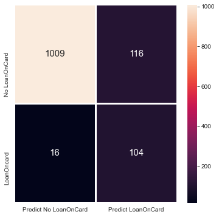

```python
y_predict=classifier_o.predict(X_test)
cm=metrics.confusion_matrix(y_test, y_predict, labels=[0, 1])

df_cm = pd.DataFrame(cm, index = [i for i in ["No LoanOnCard","LoanOncard"]],
                  columns = [i for i in ["Predict No LoanOnCard","Predict LoanOnCard"]])
plt.figure(figsize = (6,6))
sns.heatmap(df_cm, annot=True,linewidths=2, linecolor='white', fmt='g', annot_kws={"size":15})
```

```python
print(cm)
```

```
[[1009  116]
 [  16  104]]
```

**Observation**

## 4.Performance Improvement: 10

**a.Train a base model each for SVM, KNN[4marks]**

## a.1Train the base Model for SVM

```python
#Import svm model
from sklearn import svm

#Create a svm Classifier
clf = svm.SVC(kernel='linear') # Linear Kernel

#Train the model using the training sets
clf.fit(X_train, y_train)

#Predict the response for test dataset
y_pred = clf.predict(X_test)
```

**Evaluating the Model** Let's estimate how accurately the classifier or model can predict the LoanOnCard

Accuracy can be computed by comparing actual test set values and predicted values.

```python
#Import scikit-learn metrics module for accuracy calculation
from sklearn import metrics

# Model Accuracy: how often is the classifier correct?
print("Accuracy:",metrics.accuracy_score(y_test, y_pred))
```

```
Accuracy: 0.9582329317269076
```

We got a classification rate of 95.82%, considered as very good accuracy.

For further evaluation,we can check precision and recall of model.

```python
# Model Precision: what percentage of positive tuples are labeled as such?
print("Precision:",metrics.precision_score(y_test, y_pred))

# Model Recall: what percentage of positive tuples are labelled as such?
print("Recall:",metrics.recall_score(y_test, y_pred))
```

```
Precision: 0.8777777777777778
Recall: 0.6583333333333333
```

We got a precision of 87% . But recall of 65%. Precision is good but recall is not that much expected value

## a.2 Train a model with KNN

```python
# instantiate learning model (k = 9)
knn = KNeighborsClassifier(n_neighbors=9)

# fitting the model
knn.fit(X_train, y_train)

# predict the response
y_pred = knn.predict(X_test)
# evaluate accuracy
print('accuracy score when k=9',accuracy_score(y_test, y_pred))
```

```
accuracy score when k=9 0.9124497991967871
```

```python
# instantiate learning model (k = 3)
knn = KNeighborsClassifier(n_neighbors = 3)

# fitting the model
knn.fit(X_train, y_train)

# predict the response
y_pred = knn.predict(X_test)

# evaluate accuracy
print('accuracy score when n=3',accuracy_score(y_test, y_pred))

# instantiate learning model (k = 5)
knn = KNeighborsClassifier(n_neighbors=5)

# fitting the model
knn.fit(X_train, y_train)

# predict the response
y_pred = knn.predict(X_test)

# evaluate accuracy
print('accuracy score when n=5',accuracy_score(y_test, y_pred))

# instantiate learning model (k = 7)
knn = KNeighborsClassifier(n_neighbors=7)

# fitting the model
knn.fit(X_train, y_train)

# predict the response
y_pred = knn.predict(X_test)

# evaluate accuracy
print('accuracy score when k=7',accuracy_score(y_test, y_pred))


# instantiate learning model (k = 9)
knn = KNeighborsClassifier(n_neighbors=9)

# fitting the model
knn.fit(X_train, y_train)

# predict the response
y_pred = knn.predict(X_test)

# evaluate accuracy
print('accuracy score when k=9',accuracy_score(y_test, y_pred))

# instantiate learning model (k = 11)
knn = KNeighborsClassifier(n_neighbors=11)

# fitting the model
knn.fit(X_train, y_train)

# predict the response
y_pred = knn.predict(X_test)

# evaluate accuracy
print('accuracy score when k=11',accuracy_score(y_test, y_pred))
# instantiate learning model (k = 13)
knn = KNeighborsClassifier(n_neighbors=13)

# fitting the model
knn.fit(X_train, y_train)

# predict the response
y_pred = knn.predict(X_test)

# evaluate accuracy
print('accuracy score when k=13',accuracy_score(y_test, y_pred))
```

```
accuracy score when n=3 0.908433734939759
accuracy score when n=5 0.9108433734939759
accuracy score when k=7 0.9116465863453815
accuracy score when k=9 0.9124497991967871
accuracy score when k=11 0.9116465863453815
accuracy score when k=13 0.9092369477911647
```

```python
from sklearn.metrics import confusion_matrix
confusion_matrix(y_test, y_pred)
```

```
array([[1097,   28],
       [  85,   35]], dtype=int64)
```

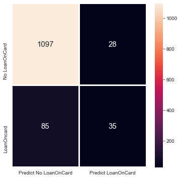

```python
# calculate accuracy measures and confusion matrix
cm=metrics.confusion_matrix(y_test, y_pred, labels=[0, 1])

df_cm = pd.DataFrame(cm, index = [i for i in ["No LoanOnCard","LoanOncard"]],
                  columns = [i for i in ["Predict No LoanOnCard","Predict LoanOnCard"]])
plt.figure(figsize = (6,6))
sns.heatmap(df_cm, annot=True,linewidths=2, linecolor='white', fmt='g', annot_kws={"size":15})
```

**b.Tune parameters/hyperparameters for each of the models wherever required and finalize a model. [3 Mark]**

```python
#### SVM Model Base
from sklearn.svm import SVC
# train the model on train set
model = SVC()
model.fit(X_train, y_train)

# print prediction results
predictions = model.predict(X_test)
print(classification_report(y_test, predictions))
```

```
              precision    recall  f1-score   support

           0       0.91      1.00      0.95      1125
           1       0.79      0.12      0.22       120

    accuracy                           0.91      1245
   macro avg       0.85      0.56      0.58      1245
weighted avg       0.90      0.91      0.88      1245
```